# Reproducible Research II

Adam M. Wilson

September 2015

## 0.1 Overview

### 0.1.1 Questions from last week?

- Got Git?

## 0.2 Homework Review

## 0.3 Today

### 0.3.1 Outline

- Project Proposal
- More Git
- More Markdown

**Guided Exploration**

- Reading files
- Introduction to `ggplot2()`

## 0.4 Project proposal

**Final project:**

dynamically generated report of a spatial analysis (minimum 12 page, maximum 30 pages).

**Project proposal:**

<1 page due next week

1. Introduction to problem/question
2. Proposed data sources
3. Proposed methods
4. Expected results

# 1 Working with Git and GitHub

## 1.1 Commit to GitHub from within RStudio

### 1.1.1 Steps:

1. Stage
2. Commit (with a message)
3. Push

## 1.2 The 3 states of files

### 1.2.1 staged, modified, committed

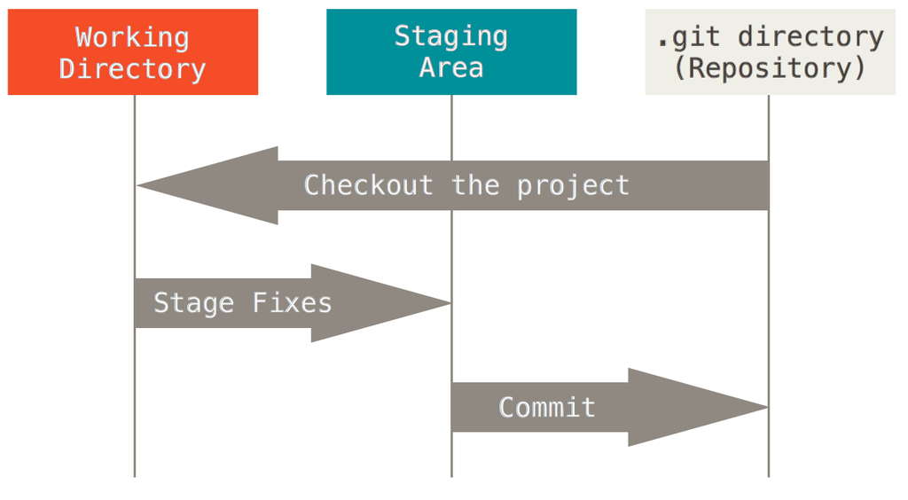

The important stuff is hidden in the `.git` folder.

## 1.3 Staging

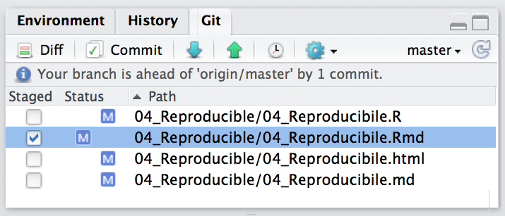

Select which files you want to commit.

## 1.4 Committing

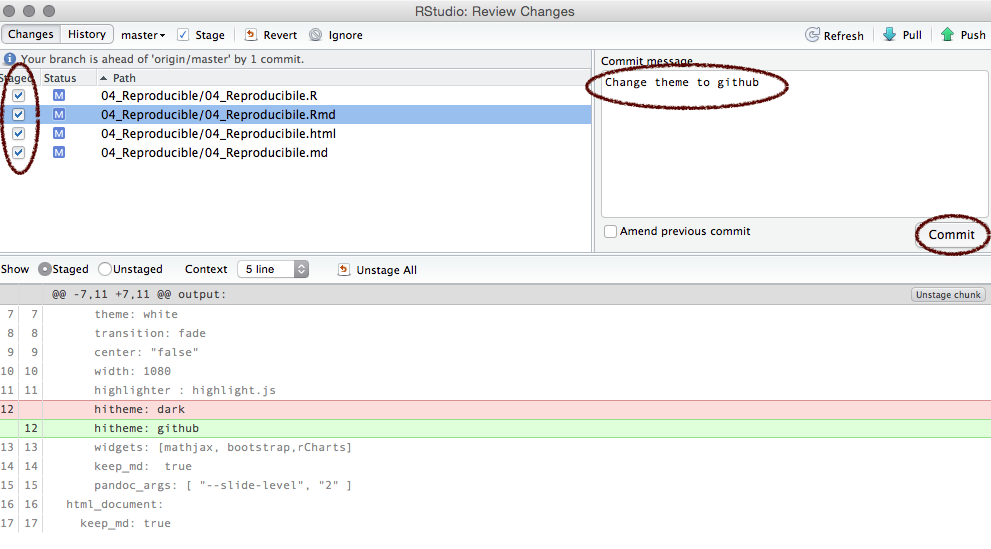

Add a *commit message* and click commit.

## 1.5 Syncing (`push`)

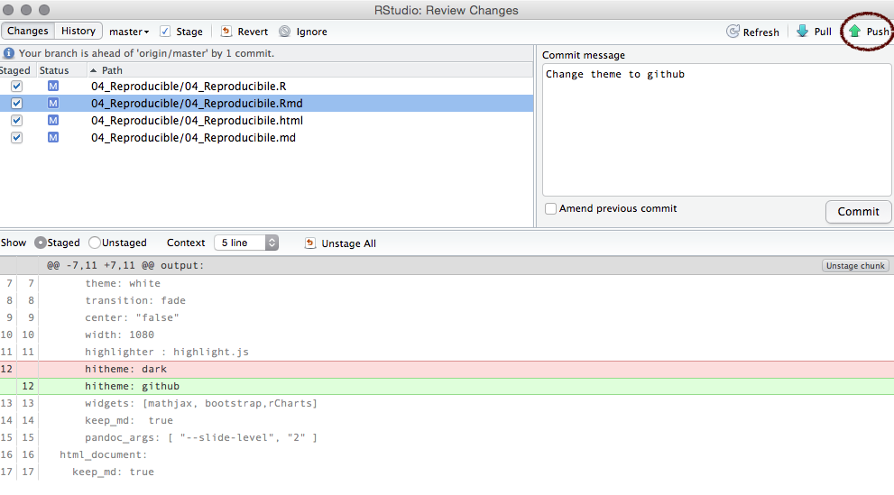

Click the green arrow to sync with GitHub.

## 1.6 Github

[figure not shown]

Files are updated/stored on GitHub

## 1.7 Git File Lifecycle

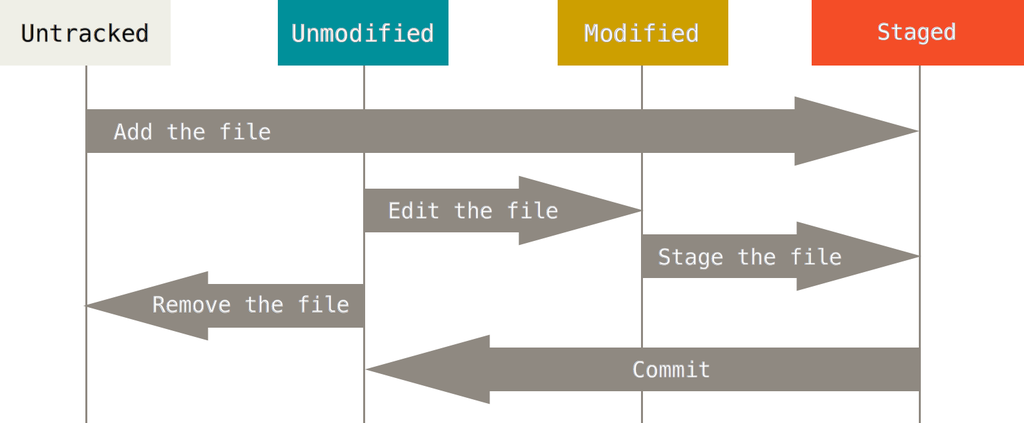

## 1.8 Git command line from RStudio

RStudio has limited functionality.

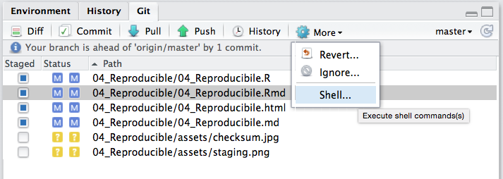

## 1.9 Git help

```
$ git help <verb>
$ git <verb> --help
$ man git-<verb>
```

For example, you can get the manpage help for the config command by running `git help config`

## 1.10 Git status

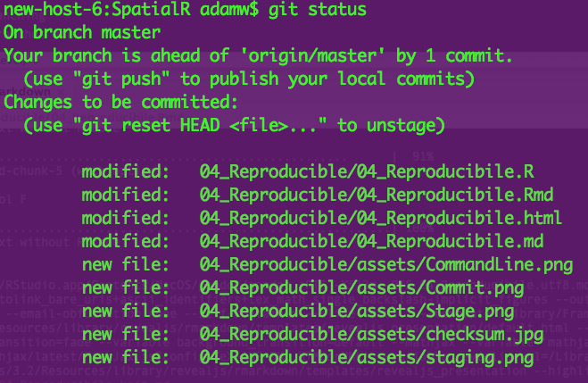

Similar to info in git tab in RStudio

## 1.11 Git config

`git config` shows you all the git configuration settings:

- `user.email`
- `remote.origin.url` (e.g. to connect to GitHub)

## 1.12 Branching

Branches used to develop features isolated from each other.

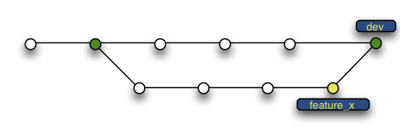

Default: *master* branch. Use other branches for development/collaboration and merge them back upon completion.

## 1.13 Basic Branching

```
$ git checkout -b devel   # create new branch and switch to it


$ git checkout master  #switch back to master
$ git merge devel  #merge in changes from devel branch
```

But we won’t do much with branching in this course…

## 1.14 Git Has Integrity

Everything *checksummed* before storage and then referred by *checksum*.

> It’s impossible to change the contents of any file or directory without Git knowing. You can’t lose information in transit or get file corruption without Git being able to detect it.

A 40-character hexadecimal SHA-1 hash:

`24b9da6552252987aa493b52f8696cd6d3b00373`

## 1.15 Checksum

A way of reducing digital information to a unique ID:

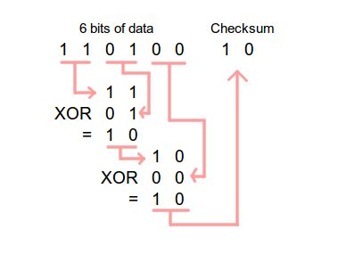

Git doesn’t care about filenames, extensions, etc. It’ the information that matters…

## 1.16 Git can do far more!

Check out the (free) book [ProGIT](https://git-scm.com/book/en/v2)

[figure not shown]

Or the [cheatsheet](https://training.github.com/kit/downloads/github-git-cheat-sheet.pdf).

## 1.17 Philosphy

Remember, the data and code are *real*, the products (tables, figures) are ephemeral…

# 2 RMarkdown

## 2.1 RMarkdown: workflow

[figure not shown]

## 2.2 RMarkdown: new file

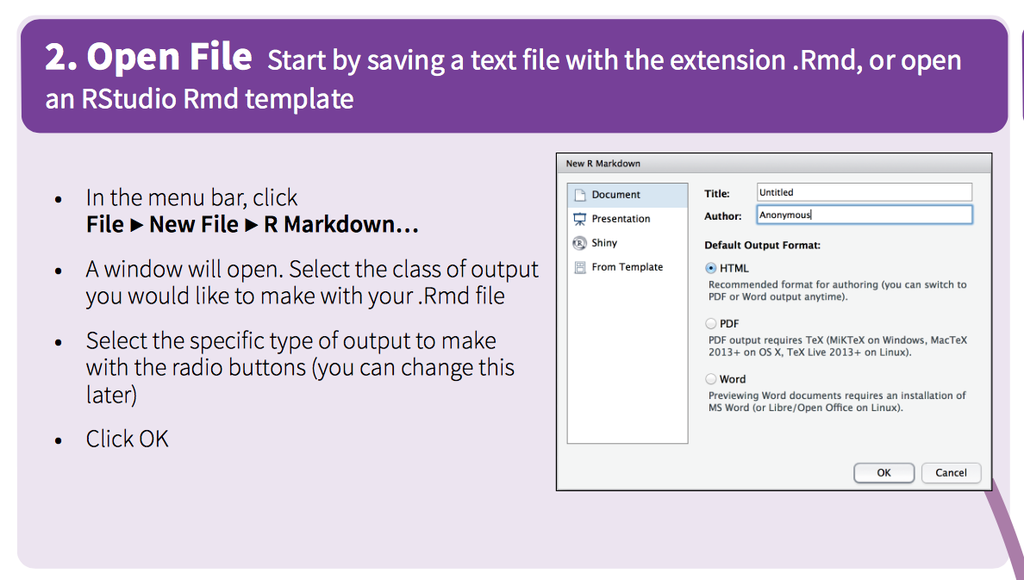

## 2.3 RMarkdown: syntax

[figure not shown]

## 2.4 RMarkdown: output

[figure not shown]

## 2.5 RMarkdown: code

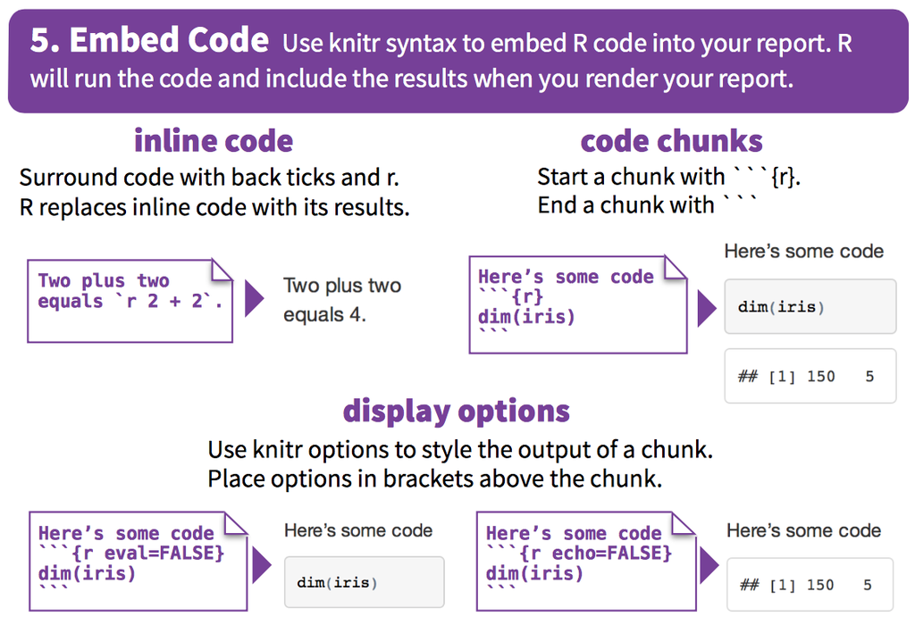

## 2.6 RMarkdown: chunks

| Option | default | effect |
| --- | --- | --- |
| `eval` | `TRUE` | Evalute the code and include the results |
| `echo` | `TRUE` | Display the code along with its results |
| `warning` | `TRUE` | Display warnings |
| `error` | `FALSE` | Display errors |
| `message` | `TRUE` | Display messages |
| `tidy` | `FALSE` | Reformat code to make it ‘tidy’ |
| `results` | “markup” | “markup”, “asis”,“hold”,“hide” |
| `cache` | `FALSE` | Cache results for future renders |
| `comment` | `"##"` | Comment character to preface results |
| `fig.width` | 7 | Width in inches for plots |
| `fig.height` | 7 | Height in inches for plots |

## 2.7 Chunk examples

R Code Chunks: Displaying Plots

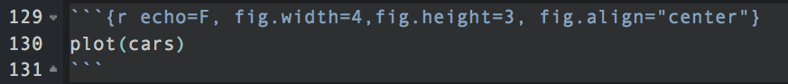

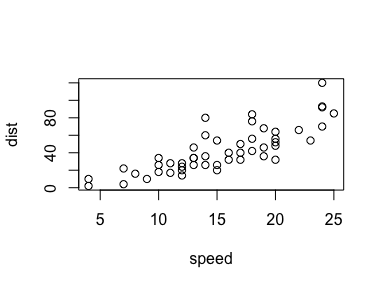

## 2.8 Global chunk options

Use chunk options throughout a document:

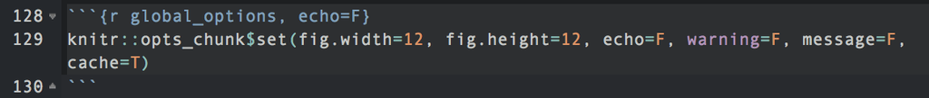

## 2.9 RMarkdown: render

[figure not shown]

## 2.10 Visualize .md on GitHub

Update the YAML header to keep the markdown file

From this:

```r
title: "Untitled"
author: "Adam M. Wilson"
date: "September 21, 2015"
output: html_document
```

To this:

```r
title: "Demo"
author: "Adam M. Wilson"
date: "September 21, 2015"
output:
  html_document:
      keep_md: true
```

And click `knit HTML` to generate the output

## 2.11 Visualize example

[figure not shown]

## 2.12 Explore markdown<->Git

1. Use *File -> New File -> R Markdown* to create a new markdown file.
2. Use the Cheatsheet to add sections (`#` and `##`) and some example narrative.
3. `Stage`, `Commit`, `Push`!
4. Make more changes then `Stage`, `Commit`, `Push`!
5. Explore the markdown file on your GitHub website.

### 2.12.1 Take 15 minutes & ask questions!

## 2.13 Colophon

Licensing: * Presentation: [CC-BY-3.0](http://creativecommons.org/licenses/by/3.0/us/) * Source code: MIT